# 20181016 hoemwork

RyanYip

### load data

```r
wagexp=read.csv("./wagexp.csv",header = TRUE)
```

### check NA value and duplicated values

```r
sum(is.na(wagexp))  # there is no NA value
```

```
## [1] 0
```

```r
wagexp=wagexp[!duplicated(wagexp),]
```

there is 206 observation

```r
predictor=c("AGE","EXP","HSDRoP","HSGRAD","ASSOC","FEMALE")
all.model=lm(WAGE~AGE+I(AGE^2)+EXP+HSDROP+HSGRAD+ASSOC+FEMALE,data = wagexp)
model.summary=summary(all.model)$coefficients
confidents=confint(all.model)
summary(all.model)
```

```
##
## Call:
## lm(formula = WAGE ~ AGE + I(AGE^2) + EXP + HSDROP + HSGRAD +
##     ASSOC + FEMALE, data = wagexp)
##
## Residuals:
##     Min      1Q  Median      3Q     Max
## -8.9088 -2.8479 -0.1728  1.9005 15.2639
##
## Coefficients:
##              Estimate Std. Error t value Pr(>|t|)
## (Intercept) -0.651324   3.630121  -0.179 0.857790
## AGE          0.684073   0.183864   3.721 0.000259 ***
## I(AGE^2)    -0.006198   0.001999  -3.101 0.002209 **
## EXP         -0.071574   0.079027  -0.906 0.366205
## HSDROP      -6.583392   1.162073  -5.665 5.12e-08 ***
## HSGRAD      -4.356037   0.815277  -5.343 2.50e-07 ***
## ASSOC       -1.959340   0.926987  -2.114 0.035796 *
## FEMALE      -2.663212   0.645894  -4.123 5.49e-05 ***
## ---
## Signif. codes:  0 '***' 0.001 '**' 0.01 '*' 0.05 '.' 0.1 ' ' 1
##
## Residual standard error: 4.132 on 198 degrees of freedom
## Multiple R-squared:  0.3989, Adjusted R-squared:  0.3777
## F-statistic: 18.77 on 7 and 198 DF,  p-value: < 2.2e-16
```

### question 1

H0:WAGE~a1*AGE+a2*I(AGE^2)+a4*HSDROP+a5*HSGRAD+a6*ASSOC+a7*FEMALE+a0

H1:WAGE~a1*AGE+a2*I(AGE^2)+a3*EXP+a4*HSDROP+a5*HSGRAD+a6*ASSOC+a7*FEMALE+a0

H0 成立的前提下: formule: t=beta3_hat/sqrt(sd(beta3) 服从自由度为n-p的t分布

### question 4

```r
cor(wagexp[,c("AGE","FEMALE","HSDROP","HSGRAD","ASSOC","EXP")])
```

```
##                AGE      FEMALE     HSDROP      HSGRAD       ASSOC
## AGE     1.00000000  0.14468871  0.1832568 -0.11462502 -0.04763059
## FEMALE  0.14468871  1.00000000  0.0220865  0.12510689 -0.08417942
## HSDROP  0.18325684  0.02208650  1.0000000 -0.34381992 -0.16231723
## HSGRAD -0.11462502  0.12510689 -0.3438199  1.00000000 -0.40404918
## ASSOC  -0.04763059 -0.08417942 -0.1623172 -0.40404918  1.00000000
## EXP     0.92394171  0.01670644  0.2862939 -0.02402402 -0.09145799
##                EXP
## AGE     0.92394171
## FEMALE  0.01670644
## HSDROP  0.28629389
## HSGRAD -0.02402402
## ASSOC  -0.09145799
## EXP     1.00000000
```

```r
car::vif(all.model)
```

```
##       AGE  I(AGE^2)       EXP    HSDROP    HSGRAD     ASSOC    FEMALE
## 57.364423 45.122317 10.620281  1.736977  1.992350  1.394490  1.257599
```

I consider that this model suffer from multicollinearity: * 1) the VIF value of AGE,EXP are larger than 10;

- 2. the correlation coefficient between ** AGE ** and ** EXPERIENCE ** is larger than 0.9, ** HSGRAD** and ** ASSOC ** also has -0.4
- 3. the ** EXPERIENCE ** estimate coefficient is **-0.071574**,which tell us that EXPERIENCE has negative effect on WAGE,this is incorrect ,it is not consistenct with commond sence.

### question 5

```r
wagexp$ln.wage=log2(wagexp$WAGE)
new.model=lm(ln.wage ~ log2(AGE)+ED*FEMALE,data=wagexp)
summary(new.model)
```

```
##
## Call:
## lm(formula = ln.wage ~ log2(AGE) + ED * FEMALE, data = wagexp)
##
## Residuals:
##      Min       1Q   Median       3Q      Max
## -1.61265 -0.40513  0.05933  0.43236  1.58232
##
## Coefficients:
##             Estimate Std. Error t value Pr(>|t|)
## (Intercept) -1.15711    0.54658  -2.117   0.0355 *
## log2(AGE)    0.51568    0.09242   5.580 7.72e-08 ***
## ED           0.13245    0.02175   6.091 5.63e-09 ***
## FEMALE      -0.56422    0.44364  -1.272   0.2049
## ED:FEMALE    0.01495    0.03298   0.453   0.6509
## ---
## Signif. codes:  0 '***' 0.001 '**' 0.01 '*' 0.05 '.' 0.1 ' ' 1
##
## Residual standard error: 0.606 on 201 degrees of freedom
## Multiple R-squared:  0.3796, Adjusted R-squared:  0.3673
## F-statistic: 30.75 on 4 and 201 DF,  p-value: < 2.2e-16
```

```r
new.model.summary=summary(new.model)$Coefficient
new.model.confident=confint(new.model)
```

Based on summary of new model,the beta1 coefficiet is 0.51568 , it represent that,ln(AGE)has a positive affect on ln(wage) ,when ln(age) add one unit,and ln(wage) add 0.51568 unit

### question 7

Run the following regression model:

- step 1) ln(wage )~ b_0+ b_1*ln(AGE) + b_2*FEMALE + b_3*ED+ be_4FEMALE*ED+sigma
- step 2) sigma_hat~phi_0+phi_1*ln(wage)_hat+phi_2*ln(wage)^2
- step 3) Retain the R-squared value from the regression(step 2):R-squre_phi
- step 4)Calculate the F-statistic or the chi-squared statistic: chi=n*R-squre_phi ~chi(3)

If either of these test statistics is significant, then you have evidence of heteroskedasticity. If not, you fail to reject the null hypothesis of homoskedasticity

```r
lnwage_hat=fitted(new.model) # y_hat
df=data.frame(res=residuals(new.model),lnwage_hat=lnwage_hat)


new2.model=lm(res~lnwage_hat+I(lnwage_hat^2),data=df)
summary(new2.model)
```

```
##
## Call:
## lm(formula = res ~ lnwage_hat + I(lnwage_hat^2), data = df)
##
## Residuals:
##      Min       1Q   Median       3Q      Max
## -1.63820 -0.38806  0.05901  0.43509  1.62120
##
## Coefficients:
##                 Estimate Std. Error t value Pr(>|t|)
## (Intercept)       1.6086     1.2686   1.268    0.206
## lnwage_hat       -1.0809     0.8367  -1.292    0.198
## I(lnwage_hat^2)   0.1773     0.1365   1.299    0.195
##
## Residual standard error: 0.6005 on 203 degrees of freedom
## Multiple R-squared:  0.008248,   Adjusted R-squared:  -0.001523
## F-statistic: 0.8441 on 2 and 203 DF,  p-value: 0.4314
```

```r
R.squre=summary(new2.model)$r.square

chi=dim(df)[1]*R.squre
pchisq(chi,df=3)
```

```
## [1] 0.3628579
```

### question 8

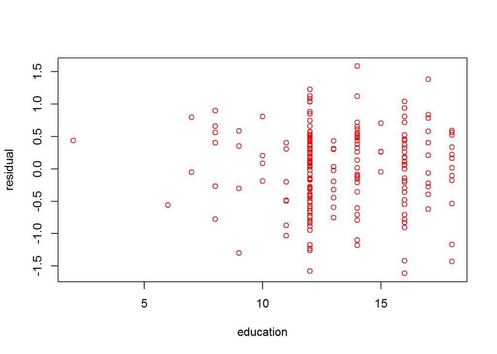

```r
Res=residuals(new.model)
plot(wagexp[,"ED"],Res,col="red",xlab="education",ylab="residual")
```

The plot show us that the distribution of the scattered points on both sides of the residual error is uniform.So I think the education variable do not look heteroskedastic.

### question 9

We can run a regression with White’s corrected standard errors(a robust linear regression),which cabn remove the effect of heteroskedasticity.

```r
require(MASS)
robust.model=rlm(ln.wage ~ log2(AGE)+ED*FEMALE,data=wagexp)
summary(robust.model)
```

```
##
## Call: rlm(formula = ln.wage ~ log2(AGE) + ED * FEMALE, data = wagexp)
## Residuals:
##      Min       1Q   Median       3Q      Max
## -1.63101 -0.40197  0.06531  0.40302  1.59067
##
## Coefficients:
##             Value   Std. Error t value
## (Intercept) -1.4996  0.5535    -2.7093
## log2(AGE)    0.5760  0.0936     6.1545
## ED           0.1366  0.0220     6.2015
## FEMALE      -0.4904  0.4493    -1.0915
## ED:FEMALE    0.0083  0.0334     0.2472
##
## Residual standard error: 0.6017 on 201 degrees of freedom
```

From the summary result of robust model ,wo know that ** beta1** is 0.5760,and in the origin model is 0.5157;and ** Std. Error,t value ** between them are also similar.Compared to question 5, we can conclude that there is almost no difference.

### question 10

I do not consider this model suffers from heteroskedasticity.

- 1. According to the question 7,we know that White’s test for heteroskedasticity on this model is not significant.So there is not enough reason to believe that this model has heteroskedasticity.And we consider it has not.
- 2. According to the question 8,the plot of residual against eduacation tells us,this model does not have heteroskedasticity.
- 3. The coefficients between this model and robust model is are so similar.It is an another reason .